# Time Series: Example 1

Samuel Burer (samuel-burer@uiowa.edu)

Updated: July 28, 2021

# Preparation

If you are following along in RStudio, to prepare for this example, choose the RStudio menu item *Session > Restart and Clear Output*. Alternatively, you can choose *Run > Restart R and Clear Output* in the notebook code window. You will also need to install the `ggplot2` and `forecast` packages and to source `code_Time_Series.R`.

```r
# install.packages(c("ggplot2", "forecast")) # Paste into console to install
source("code_Time_Series.R")
```

# Data and Getting Started

The file `data_Time_Series.Rdata` contains several time series that will be the basis of our example. In particular, we will work only with univariate time series, i.e., time series that contain just one column of data. Let’s load the data:

```r
load("data_Time_Series.Rdata")
library(readr)
HRExercise <- read_csv("HRExercise.csv",
    col_types = cols(Date = col_date(format = "%m/%d/%y"),
        Time = col_time(format = "%T"), DateTime = col_datetime(format = "%m/%d/%y %T"),
        Exercise = col_factor(levels = c("Yoga", "Walking", "Running", "Biking", "Trail Walking", "Trail Running", "Mountain Biking")),
        ExerciseValue = col_factor(levels = c("0", "1", "2", "3", "4", "5", "6")),
        Course = col_factor(levels = c("Alta Vista",
            "Deer Hollow", "Enterprise South",
            "Four Pass Loop", "Full Practice",
            "Greenway", "Hawk's Ridge", "Montreat",
            "Montreat Trails", "Restorative",
            "Riverwalk", "Southern Soul",
            "Stringers", "White Oak - Green",
            "White Sands Cove", "Whole Enchilada")),
        CourseValue = col_factor(levels = c("0", "1", "2", "3")),
        Zone = col_factor(levels = c("1", "2", "3", "4", "5")),
        IsYoga = col_factor(levels = c("0", "1")),
        IsFullPractice = col_factor(levels = c("0", "1")),
        IsSouthernSoul = col_factor(levels = c("0", "1")),
        IsOtherYoga = col_factor(levels = c("0", "1")),
        IsLessThan12HoursSinceLastYoga = col_factor(levels = c("0", "1")),
        IsLessThan24HoursSinceLastYoga = col_factor(levels = c("0", "1")),
        IsLessThan36HoursSinceLastYoga = col_factor(levels = c("0", "1")),
        IsLessThan48HoursSinceLastYoga = col_factor(levels = c("0", "1")),
        IsLessThan60HoursSinceLastYoga = col_factor(levels = c("0", "1")),
        IsLessThan72HoursSinceLastYoga = col_factor(levels = c("0", "1")),
        IsBiking = col_factor(levels = c("0", "1")),
        IsBikingAtWhiteOakGreen = col_factor(levels = c("0", "1")),
        IsBikingAtWholeEnchilada = col_factor(levels = c("0", "1")),
        IsBikingAtStringers = col_factor(levels = c("0", "1")),
        IsBikingAtRiverwalk = col_factor(levels = c("0", "1")),
        IsBikingAtGreenway = col_factor(levels = c("0", "1")),
        IsOtherBiking = col_factor(levels = c("0", "1")),
        IsLessThan12HoursSinceLastBiking = col_factor(levels = c("0", "1")),
        IsLessThan24HoursSinceLastBiking = col_factor(levels = c("0", "1")),
        IsLessThan36HoursSinceLastBiking = col_factor(levels = c("0", "1")),
        IsLessThan48HoursSinceLastBiking = col_factor(levels = c("0", "1")),
        IsLessThan60HoursSinceLastBiking = col_factor(levels = c("0", "1")),
        IsLessThan72HoursSinceLastBiking = col_factor(levels = c("0", "1")),
        IsWalking = col_factor(levels = c("0", "1")),
        IsWalkingAtHawksRidge = col_factor(levels = c("0", "1")),
        IsWalkingAtFourPassLoop = col_factor(levels = c("0", "1")),
        IsWalkingAtRiverwalk = col_factor(levels = c("0", "1")),
        IsOtherWalking = col_factor(levels = c("0", "1")),
        IsLessThan12HoursSinceLastWalking = col_factor(levels = c("0", "1")),
        IsLessThan24HoursSinceLastWalking = col_factor(levels = c("0", "1")),
        IsLessThan36HoursSinceLastWalking = col_factor(levels = c("0", "1")),
        IsLessThan48HoursSinceLastWalking = col_factor(levels = c("0", "1")),
        IsLessThan60HoursSinceLastWalking = col_factor(levels = c("0", "1")),
        IsLessThan72HoursSinceLastWalking = col_factor(levels = c("0", "1")),
        IsRunning = col_factor(levels = c("0", "1")),
        IsRunningAtHawksRidge = col_factor(levels = c("0", "1")),
        IsRunningAtStringers = col_factor(levels = c("0", "1")),
        IsRunningAtRiverwalk = col_factor(levels = c("0", "1")),
        IsOtherRunning = col_factor(levels = c("0", "1")),
        IsLessThan12HoursSinceLastRunning = col_factor(levels = c("0", "1")),
        IsLessThan24HoursSinceLastRunning = col_factor(levels = c("0", "1")),
        IsLessThan36HoursSinceLastRunning = col_factor(levels = c("0", "1")),
        IsLessThan48HoursSinceLastRunning = col_factor(levels = c("0", "1")),
        IsLessThan60HoursSinceLastRunning = col_factor(levels = c("0", "1")),
        IsLessThan72HoursSinceLastRunning = col_factor(levels = c("0", "1")),
        IsHawksRidge = col_factor(levels = c("0", "1")),
        IsRiverwalk = col_factor(levels = c("0", "1")),
        IsWholeEnchilada = col_factor(levels = c("0", "1")),
        IsWhiteOakGreen = col_factor(levels = c("0", "1")),
        IsStringers = col_factor(levels = c("0", "1")),
        IsZone1 = col_factor(levels = c("0", "1")),
        IsLessThan12HoursSinceLastZone1 = col_factor(levels = c("0", "1")),
        IsLessThan24HoursSinceLastZone1 = col_factor(levels = c("0", "1")),
        IsLessThan36HoursSinceLastZone1 = col_factor(levels = c("0", "1")),
        IsLessThan48HoursSinceLastZone1 = col_factor(levels = c("0", "1")),
        IsLessThan60HoursSinceLastZone1 = col_factor(levels = c("0", "1")),
        IsLessThan72HoursSinceLastZone1 = col_factor(levels = c("0", "1")),
        IsZone2 = col_factor(levels = c("0", "1")),
        IsLessThan12HoursSinceLastZone2 = col_factor(levels = c("0", "1")),
        IsLessThan24HoursSinceLastZone2 = col_factor(levels = c("0", "1")),
        IsLessThan36HoursSinceLastZone2 = col_factor(levels = c("0", "1")),
        IsLessThan48HoursSinceLastZone2 = col_factor(levels = c("0", "1")),
        IsLessThan60HoursSinceLastZone2 = col_factor(levels = c("0", "1")),
        IsLessThan72HoursSinceLastZone2 = col_factor(levels = c("0", "1")),
        IsZone3 = col_factor(levels = c("0", "1")),
        IsLessThan12HoursSinceLastZone3 = col_factor(levels = c("0", "1")),
        IsLessThan24HoursSinceLastZone3 = col_factor(levels = c("0", "1")),
        IsLessThan36HoursSinceLastZone3 = col_factor(levels = c("0", "1")),
        IsLessThan48HoursSinceLastZone3 = col_factor(levels = c("0", "1")),
        IsLessThan60HoursSinceLastZone3 = col_factor(levels = c("0", "1")),
        IsLessThan72HoursSinceLastZone3 = col_factor(levels = c("0", "1")),
        IsZone4 = col_factor(levels = c("0", "1")),
        IsLessThan12HoursSinceLastZone4 = col_factor(levels = c("0", "1")),
        IsLessThan24HoursSinceLastZone4 = col_factor(levels = c("0", "1")),
        IsLessThan36HoursSinceLastZone4 = col_factor(levels = c("0", "1")),
        IsLessThan48HoursSinceLastZone4 = col_factor(levels = c("0", "1")),
        IsLessThan60HoursSinceLastZone4 = col_factor(levels = c("0", "1")),
        IsLessThan72HoursSinceLastZone4 = col_factor(levels = c("0", "1")),
        IsZone5 = col_factor(levels = c("0", "1")),
        IsLessThan12HoursSinceLastZone5 = col_factor(levels = c("0", "1")),
        IsLessThan24HoursSinceLastZone5 = col_factor(levels = c("0", "1")),
        IsLessThan36HoursSinceLastZone5 = col_factor(levels = c("0", "1")),
        IsLessThan48HoursSinceLastZone5 = col_factor(levels = c("0", "1")),
        IsLessThan60HoursSinceLastZone5 = col_factor(levels = c("0", "1")),
        IsLessThan72HoursSinceLastZone5 = col_factor(levels = c("0", "1")),
        IsLessThan12HoursSinceLastAnything = col_factor(levels = c("0", "1")),
        IsLessThan24HoursSinceLastAnything = col_factor(levels = c("0", "1")),
        IsLessThan36HoursSinceLastAnything = col_factor(levels = c("0", "1")),
        IsLessThan48HoursSinceLastAnything = col_factor(levels = c("0", "1")),
        IsLessThan60HoursSinceLastAnything = col_factor(levels = c("0", "1")),
        IsLessThan72HoursSinceLastAnything = col_factor(levels = c("0", "1"))
        ))
```

The data sets are as follows:

- `cpi` = annual Consumer Price Index since 1947, which is indexed to the value 1.0
- `elec` = monthly net electricity generation in the U.S. (in kWh)
- `google` = daily closing price (in $) of Google stock (start date = February 25, 2013)
- `lettuce` = monthly Producer Price Index for lettuce since 1947; the average of 1982 is indexed to 100.0
- `qc` = quality control data; 5 measurements per day, for 25 consecutive days; measurements are taken at 6:00, 10:00, 14:00, 18:00, and 22:00
- `rain` = annual rainfall (in inches) in Philadelphia
- `soda` = monthly soda sales (in thousands of cases) for a soda distributor
- `ui` = total Fall plus Spring semester enrollment at the University of Iowa

In the code chunk below, you can uncomment whichever series you would like to work with in this example. Then the time series will be referenced in the object called `myts` throughout this example.

```r
# myts <- cpi
# myts <- elec
myts <- google
# myts <- lettuce
# myts <- qc
# myts <- rain
# myts <- soda
# myts <- ui

efficiency <- data.frame(HRExercise$Efficiency)
efficiency <- ts(data = efficiency, start = c(as.Date(HRExercise$DateTime[1])), end=c(as.Date(HRExercise$DateTime[113])), frequency = 1)
```

Let’s first look at the raw data:

```r
myts
```

```
Time Series:
Start = 1
End = 200
Frequency = 1
  [1] 392.8300 392.5121 397.3059 398.0113 400.4902 408.0957 416.5905 413.0038 413.6099 413.0734 414.7127 411.1310 409.9884 408.1156 404.5190 401.2850 403.0386
 [18] 404.7227 403.0088 402.5369 402.2040 403.5851 398.7366 394.5290 398.0063 403.8931 400.4952 394.9661 388.9950 384.9214 386.3124 392.5369 392.6412 392.4724
 [35] 388.4386 394.1216 388.7516 380.4803 397.3506 397.4698 401.3397 404.0967 401.9358 398.1206 406.8836 409.6208 407.5642 412.1245 420.1275 427.9913 425.8453
 [52] 433.9923 432.9243 437.2710 435.9297 440.6838 454.9857 449.0146 451.6524 451.3295 450.5546 441.8363 438.5427 433.8383 437.7876 431.3495 432.5666 432.7951
 [69] 431.0117 426.7742 427.0723 429.5263 437.0226 442.2337 437.0623 433.1726 435.6664 434.6927 440.2615 447.4001 447.4299 439.5114 437.6187 432.0847 430.3013
 [86] 434.0022 435.7012 437.3405 441.0713 438.3043 440.3510 443.8581 449.6206 449.6952 450.0677 457.1467 458.5178 459.3573 456.8337 456.3072 452.3976 445.4031
[103] 452.4075 448.9798 448.5327 440.9818 439.8144 438.2844 442.5814 441.0067 449.1885 450.3559 449.5759 445.3882 442.4473 443.4458 442.3281 439.8939 437.7777
[120] 432.0946 427.0524 425.6863 430.0281 429.9138 431.8562 434.0320 432.2933 430.3957 422.3282 421.5333 424.9511 420.7137 427.4101 432.9987 436.9381 436.9481
[137] 441.1557 441.4637 445.1994 443.6445 441.6624 441.0117 440.1920 448.7414 446.2923 448.6371 440.3857 440.5546 435.7807 436.2476 435.3634 435.1249 440.6341
[154] 441.1259 435.2144 433.3564 430.0728 424.0768 425.1647 431.3147 433.1776 435.2243 438.1552 446.1135 441.5233 502.4371 498.4083 500.2464 512.3725 509.4615
[171] 504.3199 504.2205 514.7719 511.8807 511.9602 510.2016 509.7396 507.4595 508.0705 500.7183 504.7322 502.0298 502.6209 512.8991 514.2701 513.4406 512.4421
[188] 509.2876 507.8519 513.6939 512.6110 519.5856 525.7853 528.1201 526.3715 523.8329 523.2269 525.6710 525.2537 531.4783
```

```r
efficiency
```

```
Time Series:
Start = 18721
End = 18835
Frequency = 1
  [1] 0.05555556 0.05215827 0.05666114 0.05372807 0.05718954 0.05695793 0.05341880 0.04769413 0.05534512 0.05971034 0.05544810 0.06065163 0.05992982 0.04919227
 [15] 0.05369630 0.05084135 0.05304983 0.05367935 0.05555556 0.06861345 0.05438597 0.10193237 0.04706273 0.05416667 0.05139551 0.05992184 0.07937956 0.05811404
 [29] 0.05878831 0.05638269 0.04733871 0.05762411 0.05670599 0.05927835 0.05884880 0.05206698 0.04430180 0.05685619 0.05000000 0.05772569 0.05512360 0.10246914
 [43] 0.05585106 0.08233203 0.05659091 0.05569728 0.05072464 0.05868479 0.04910526 0.05119048 0.06435489 0.10299807 0.05998168 0.04991127 0.05828901 0.05798219
 [57] 0.05828901 0.05517615 0.05398842 0.09075839 0.04905263 0.05351906 0.04786115 0.05555556 0.06132075 0.09311741 0.05746016 0.05538556 0.08555663 0.05986842
 [71] 0.05767077 0.05534512 0.04247104 0.05814556 0.05845424 0.07523686 0.06207912 0.09730691 0.08639144 0.06228956 0.05250655 0.06023135 0.07261318 0.11438224
 [85] 0.09784483 0.08523490 0.08651586 0.09730056 0.06250000 0.08576944 0.05925744 0.06313282 0.07886699 0.04008373 0.03682402 0.03754205 0.03745083 0.08775655
 [99] 0.07801418 0.06168764 0.05848471 0.08405657 0.11009934 0.10545454 0.10689655 0.05705508 0.06165413 0.10219178 0.05711572 0.07027972 0.04764493 0.11492919
[113] 0.04482263 0.05555556 0.05215827
```

The command `autoplot(...)` can be used to provide a quick plot of the time series.

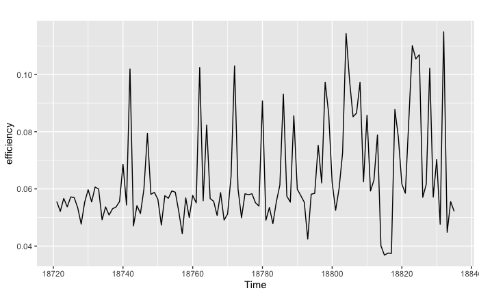

```r
#autoplot(myts)
autoplot(efficiency)
```

If the time series exhibits unstable variation (or unstable fluctuation) over time, you should log the time series. You should also log the time series if you suspect an exponential trend over time. If so, you can uncomment the following two lines to resave `myts` in logged form and print a new plot.

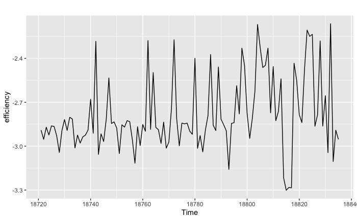

```r
#myts <- log(myts)
#autoplot(myts)

efficiency <- log(efficiency)
autoplot(efficiency)
```

If you do decide to log your time series, then keep this in mind for the rest of the example. Any analysis will be in the log, and you’ll need to do exp to get the analysis back in the original data.

# Exploration

Before doing any sophisticated analysis of a time series, it is important to get a basic feel for the data. One of the best ways is to look at the decomposition of `myts`, which breaks the time series down into a trend component, a seasonal component (as applicable), and a remainder component. Pay attention to the $y$ scales in the decomposition plot!

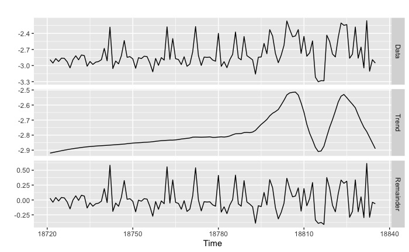

```r
#decomp <- mstl(myts)
#autoplot(decomp)

decomp_efficiency <- mstl(efficiency)
autoplot(decomp_efficiency)
```

It’s also helpful to know if the series has any autocorrelation issues, which can be viewed using the `Acf(...)` function. Note the capital letter “A” but lowercase letters “cf”. Autocorrelation can also reveal any seasonality patterns—which you may or may not already be aware of.

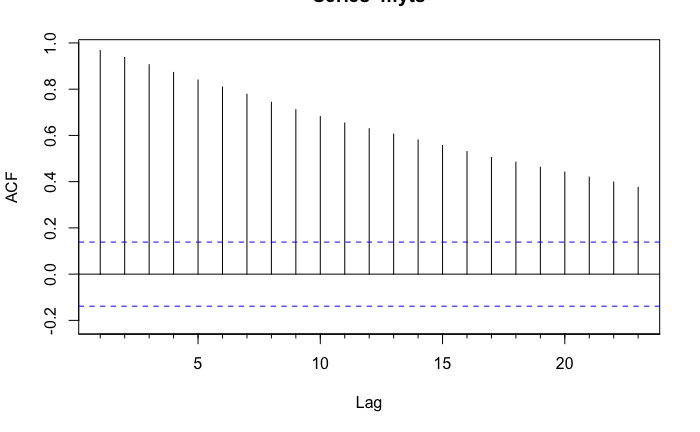

```r
Acf(myts)
```